# DEanalysis_a1881267

Chano Ranwala

2023-11-20

## Set up of libraries

As shown below the libraries required for this was set up, including providing a black and white global plot setting. Note that throughout the Rmarkdown `echo = FALSE` parameter was not added to the code chunk to as I wanted the printing of the R code that helped generate the results. The file below highlights all the codes I used to do my analysis on the final article submission.

```r
# packages for DE analysis
library(tidyverse)
library(limma)
library(edgeR)

# packages for plot
library(ggplot2)
library(ggrepel)
library(reshape2)
library(scales)
library(ggsci)
library(Glimma)

# clear workspace
rm(list = ls())

# global plot setting
theme_set(theme_bw())
```

## Getting the gene annotation information

Gene annotation information was uploaded as shown below. This code below made the gene_anno_df data table that allows us to get the gene annotation information. Duplicates have been removed and the row names have been set. Model_name correlates to gene name. It provides us with a description of the genes as well.

```r
#Get gene annotation information
gene_anno_df <- read.delim("https://www.arabidopsis.org/download_files/Genes/TAIR10_genome_release/TAIR10_functional_descriptions")
gene_anno_df$Model_name <- gsub("\\..+", "", gene_anno_df$Model_name)
gene_anno_df <- gene_anno_df[!duplicated(gene_anno_df$Model_name), ]
rownames(gene_anno_df) <- gene_anno_df$Model_name
```

As shown below, the star_dir file and count_files were made. We basically set the Star directory file path. We also retrieved all files that end with ReadsPerGene.out.tab which means all the different replicates were retrived.

```r
star_dir <- file.path("~/major_project/04_results/03_aligned_data")
count_files <- list.files(path = star_dir, pattern = "ReadsPerGene.out.tab$", full.names = T)
```

```r
#This made the firstFile_df and raw_count_mt
firstFile_df <- read.delim(count_files[1], header = F)
firstFile_df <- firstFile_df[-c(1:4), ]
raw_count_mt <- matrix(0, nrow(firstFile_df), length(count_files))
rownames(raw_count_mt) <- firstFile_df[, 1]
colnames(raw_count_mt) <- rep("temp", length(count_files))

#This made the firstFile_df and raw_count_mt
for(i in 1:length(count_files)){
  sample_name <- gsub(".+\\/", "", count_files[i])
  sample_name <- gsub("\\..+", "", sample_name)
  tmp_df <- read.delim(count_files[i], header = F)
  raw_count_mt[,i] <- tmp_df[-c(1:4), 2]
  colnames(raw_count_mt)[i] <- sample_name
}

count_genes <- gene_anno_df[rownames(raw_count_mt),]
count_genes$gene_name <- rownames(raw_count_mt)
rownames(count_genes) <- count_genes$gene_name

raw_count_df <- cbind(gene_name = rownames(raw_count_mt), raw_count_mt)
write.csv(raw_count_df, file = "~/major_project/04_results/04_DE/Table1_reference_gene_raw_count.csv", row.names = F)
```

```r
counts <- raw_count_mt
samples <- colnames(raw_count_mt)
groups <- gsub("_rep.+$", "", colnames(raw_count_mt))
genes <- count_genes
dgeList<- DGEList(counts = raw_count_mt,
    samples = samples,
    group = groups,
    genes = count_genes)
```

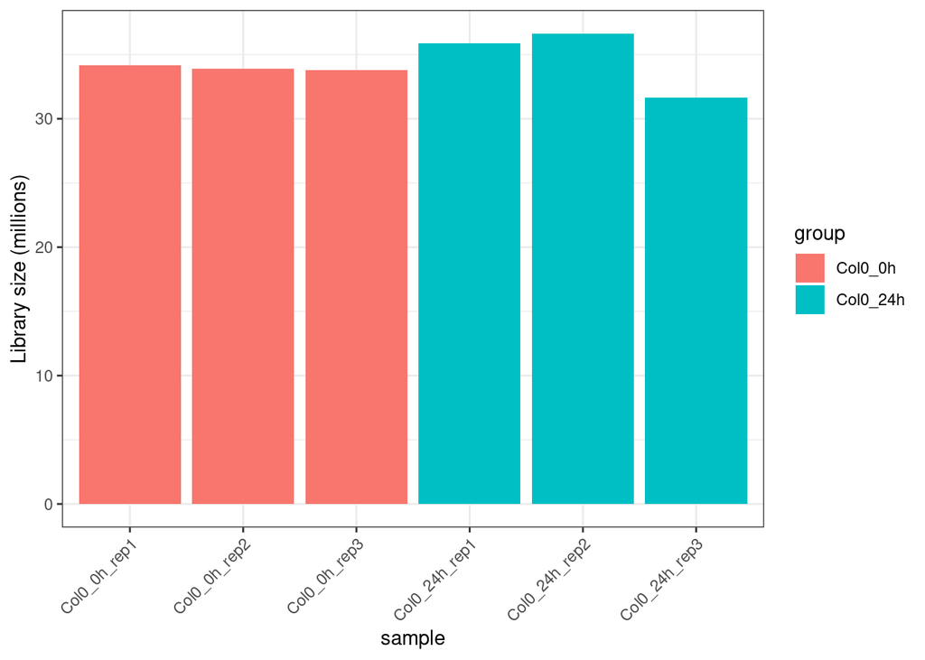

```r
dgeList$samples %>%
  rownames_to_column("sample") %>%
  ggplot(aes(x = sample, y = lib.size / 1e6, fill = group)) +
  geom_bar(stat = "identity") +
  ylab("Library size (millions)") +
  theme(axis.text.x = element_text(angle = 45, hjust = 1))
```

When sequencing the reads, we recieved different number of genes mapped to the genome for each replicate. Therefore we used the following command to normalise read counts based on the library of each sample.

```r
dgeList <- calcNormFactors(dgeList)
```

## Statistical analysis based on DGEList

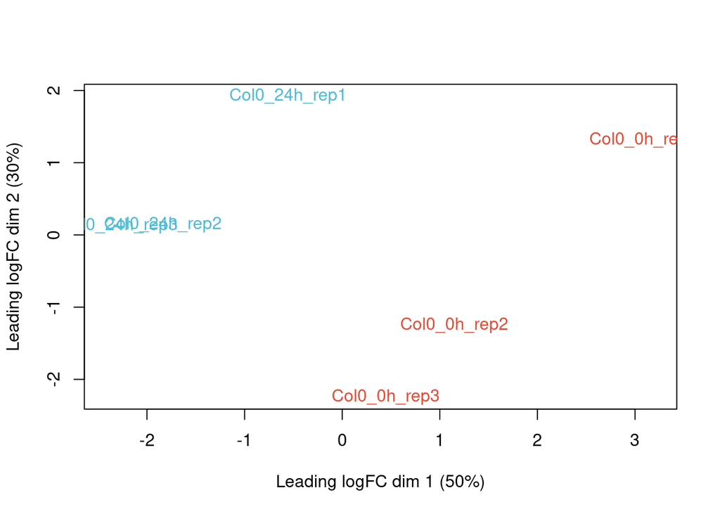

```r
cols = pal_npg("nrc", alpha=1)(2)
plotMDS(dgeList, labels = dgeList$samples$type, col = cols[dgeList$samples$group])
```

Our samples our grouped correctly as per the generated plot. Different conditions ( 0h versus 24h) were grouped together. No different conditions were mixed together. A clear pattern of separation was noticed.

After the overall gene expression was determined, we utilised a counts per milllion factor to have a look at the normalised read conda value for each gene.

```r
head(cpm(dgeList))
```

```
##           Col0_0h_rep1 Col0_0h_rep2 Col0_0h_rep3 Col0_24h_rep1 Col0_24h_rep2
## AT1G01010   16.4044849   24.9347892   32.1282941    36.7047083    33.8887020
## AT1G01020    9.4275335   10.9980750   10.4616553    10.0393906    11.4067106
## AT1G01030    3.0560200    2.9677345    2.1749231     1.5378257     1.8504833
## AT1G01040   49.1269637   55.1358524   55.3917118    59.5109539    72.0583730
## AT1G01046    0.3459645    0.2618589    0.4129601     0.2321246     0.4419065
## AT1G01050  117.0225032   89.2357041   78.5174762    65.2270230    69.8212215
##           Col0_24h_rep3
## AT1G01010     44.308265
## AT1G01020     10.446934
## AT1G01030      1.094441
## AT1G01040     65.301627
## AT1G01046      0.497473
## AT1G01050     58.237510
```

This gives the first 6 genes and how they are expressed within samples.

## Applying further adjustments and filtering

Filtrations of low expression henees is very important as it will allow the statistical power of the study to increase. The expression intensity of all genes in all samples were plotted against their density using the following command. Removed genes that express less than 1 intensity level (CPM ). A summary of the genes that fulfilled this condition was also checked

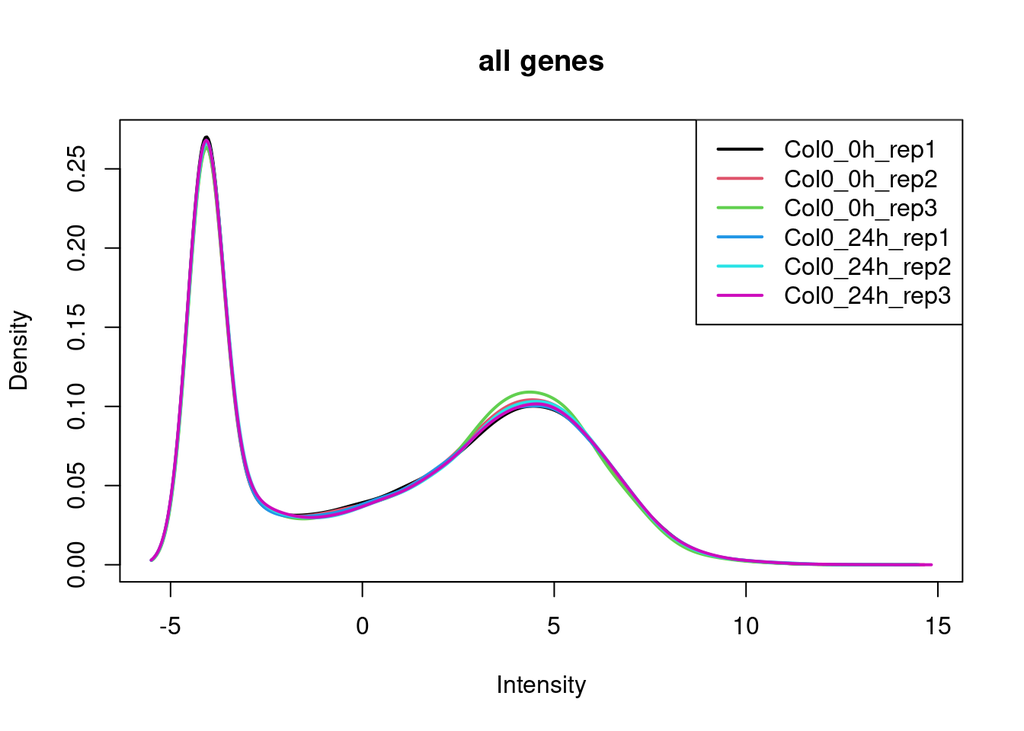

```r
plotDensities(cpm(dgeList, log = TRUE), main = "all genes", legend = "topright")
```

```r
genes2keep <- rowSums(cpm(dgeList) > 1) > 3
summary(genes2keep)
```

```
##    Mode   FALSE    TRUE
## logical   14917   18693
```

Prior to conducting the statistical testing, the low expressed genes ( low count ) needed to be removed out as they reduce the statistical power of a study. After visualising the data as counts per million (CPM) that shows the abundancy of each gene in each sample (through the code above), a plot was constructed to visualise the CPM values of all genes in all samples. Figure generated by the code above demonstrates many genes that have less than 0 logCPM counts, which needs to be filtered out. Based on the Bioconductor instruction manual (Visualization of negative log CPM values (bioconductor.org) visualisation of negative logCPM values are normal, and simply requires filtering out.

The final plot with the filtered genes were checked through the command below.

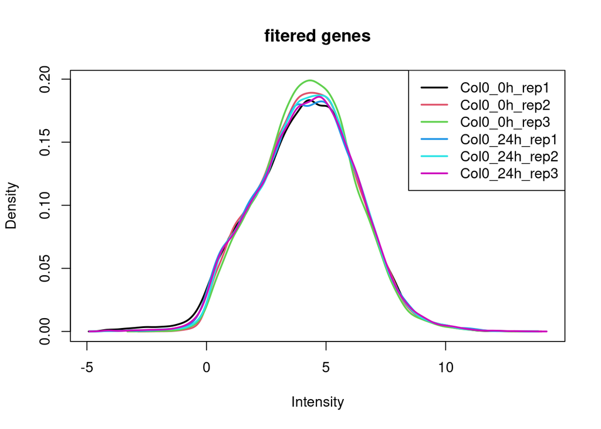

```r
plotDensities(cpm(dgeList, log = TRUE)[genes2keep, ], main = "fitered genes", legend = "topright")
```

Dataset was filtered that allowed only the genes with good abundances remained in dgeList.

```r
dgeList <- dgeList[genes2keep, ]
```

### Dispersion calculation

The following design shows a matrix that states which samples belong to which group. The dispersion was then estimated, which allowed to proceed with differential expression analysis.

```r
design <- model.matrix(~0 + group, data = dgeList$samples)
design
```

```
##               groupCol0_0h groupCol0_24h
## Col0_0h_rep1             1             0
## Col0_0h_rep2             1             0
## Col0_0h_rep3             1             0
## Col0_24h_rep1            0             1
## Col0_24h_rep2            0             1
## Col0_24h_rep3            0             1
## attr(,"assign")
## [1] 1 1
## attr(,"contrasts")
## attr(,"contrasts")$group
## [1] "contr.treatment"
```

```r
dgeList <- estimateDisp(dgeList, design = design)
```

## Statistical Significance testing

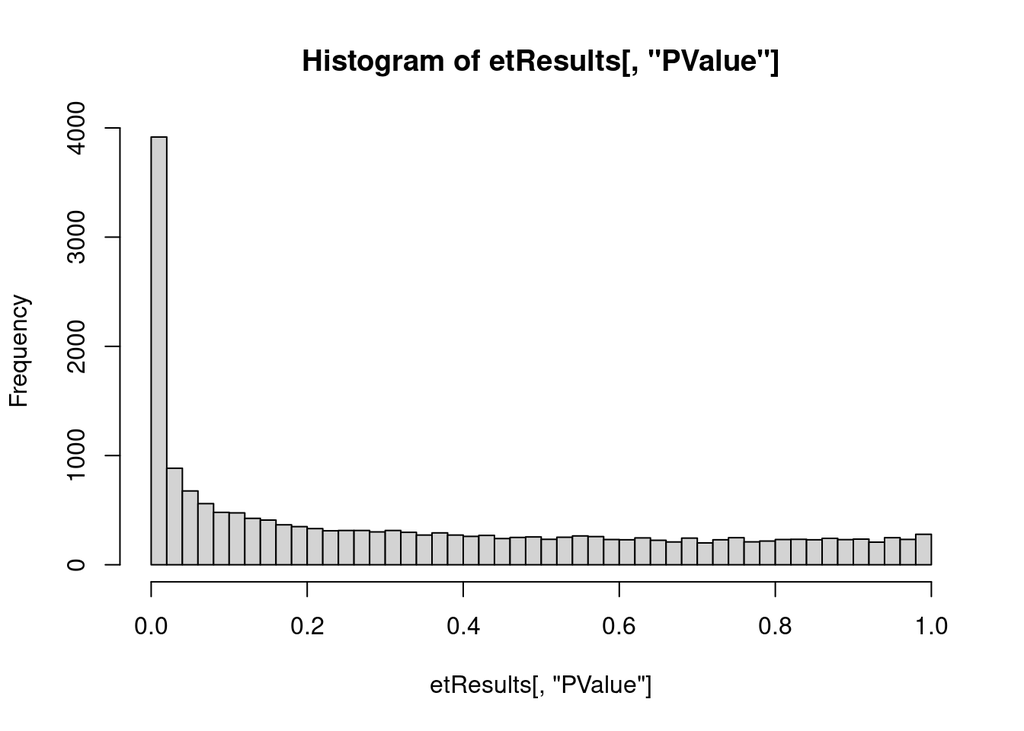

```r
etResults <- exactTest(dgeList, pair = 1:2)$table
hist(etResults[,"PValue"], breaks= 50)
```

```r
etResults <- etResults %>%
  rownames_to_column("Geneid") %>%
  mutate(FDR = p.adjust(PValue)) %>%
  arrange(PValue) %>%
  as_tibble()
```

In the final etResults table, I wanted to see which genes were overexpressed and which genes were down regulated using the code below. This was for me to count results many genes were positively expressed and which were negatively expressed, but these are from all the filtered genes, these counts are not a representation of the finalised significant results.

```r
positive_count <- sum(etResults[, 2] > 0)
negative_count <- sum(etResults[, 2] < 0)
# Print the counts
cat("Positive count:", positive_count, "\n")
```

```
## Positive count: 9285
```

```r
cat("Negative count:", negative_count, "\n")
```

```
## Negative count: 9408
```

## Finalising the siginifcantly expressed data by adjusting for false error rates

Finally, we make the table with significantly expressed genes. The FDR was set to 0.01 while the logFC was set to more than 1. False Discovery rate test (FDR) was conducted to correct for any errors. 9285 overexpressed genes were identified, followed by 9408 genes which were downregulated; however, these values are from all genes, not the statistically determined expressed genes. I also checked how many significant genes are present. The final CSV file with significant gene are now made. This is needed for further KEGG pathway analysis using DAVID.

```r
sigGenes <- filter(etResults, FDR< 0.01, abs(logFC) > 1)$Geneid


#write CSV file with significantly differentionally expressed genes
write.csv(etResults[etResults$Geneid %in% sigGenes, ],
            file = "~/major_project/04_results/04_DE/Table2_sigGenes.csv",
            row.names = F)
result_df <- read.csv("~/major_project/04_results/04_DE/Table2_sigGenes.csv", header = TRUE)

# Count the number of significant genes (excluding the header row)
num_sig_genes <- nrow(result_df)
cat("Number of significant genes:", num_sig_genes)
```

```
## Number of significant genes: 455
```

Now I checked out of those significant genes, which ones were upregulated ( positive count) and which were downregulated (negative count).

```r
# Print the number of significant genes
positive_count <- sum(result_df[, 2] > 0)
negative_count <- sum(result_df[, 2] < 0)

# Print the counts
cat("Positive count:", positive_count, "\n")
```

```
## Positive count: 236
```

```r
cat("Negative count:", negative_count, "\n")
```

```
## Negative count: 219
```

Finally, the differentially expressed genes which were statistically determined were plotted as a MA-plot in figure generated by code below. The benefit of the MA plot would be how the spread of the different p values of the statistically significant genes can be pinpointed out through the colour. The upregulation or down regulation of a significantly expressed gene against their expression level is shown below. Based on final results, using the previous code for positive_count and negative_count 455 genes were identified to be statistically significant in terms of expression, with 236 of genes being upregulated and 219 being downregulated. This also hints towards that majority of the involved genes that are statistically significant differentially expressed at 0h versus 24 hours are upregulated. However, as both gene counts for upregulation and downregulation were relatively the same, we deduce that almost equal amount of the statistically significantly expressed genes at 25 hours are either upregulated or downregulated.

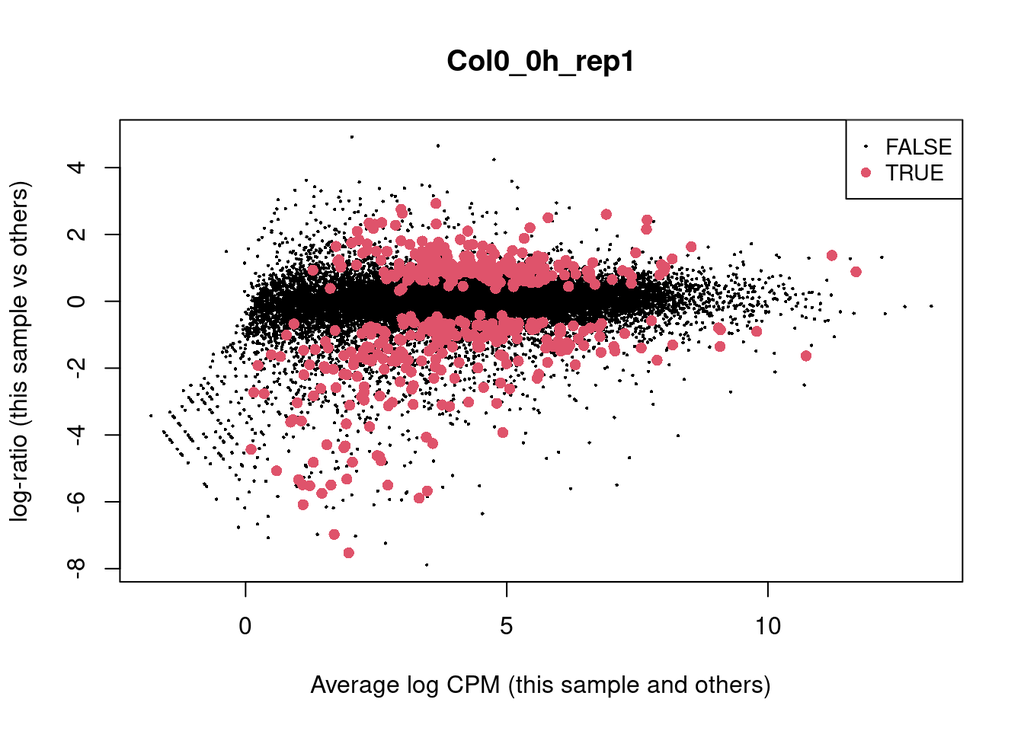

```r
plotMD(dgeList, status = rownames(dgeList) %in% sigGenes)
```

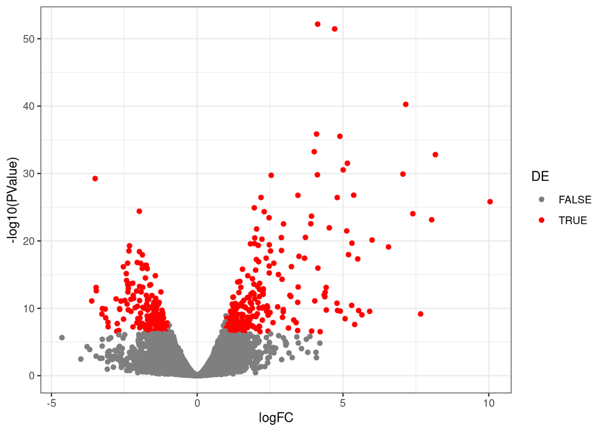

```r
etResults %>%
  mutate(DE = Geneid %in% sigGenes) %>%
  ggplot(aes(x = logFC, y = -log10(PValue),colour = DE)) +
  geom_point() +
  scale_colour_manual(values = c("grey50", "red"))
```

## Glimma plot

Finally a Glimma plot folder was made. This allowed an interactive HTML plot to be generated that shows all genes together alongside their information, relative normalised expression value and expression at 0h versus 24h. This can be found in the major_project folder under student number a1881267.

```r
DEs <- decideTests(exactTest(dgeList), adjust.method = "fdr", p.value = 0.01, lfc = 1)
glMDPlot(exactTest(dgeList), counts = cpm(dgeList, log = TRUE),
        groups = dgeList$samples$group,
        status = DEs[, 1],
        main="MD plot: Col_0_normal_light_vs_Col_0_mock",
        side.main = "ID", side.ylab = "Expression (CPM)",
        sample.cols = pal_npg()(2)[dgeList$samples$group],
        folder = "glimmer_plot", launch = FALSE)
```

End.